# Principal Component Regression - US Crime

Hannah Pavlovich

2024-02-04

*Using crime data from the file uscrime.txt (http://www.statsci.org/data/general/uscrime.txt, description at [http://www.statsci.org/data/general/uscrime.html),](http://www.statsci.org/data/general/uscrime.html),)

The purpose of this portion is to apply Principal Component Analysis and then create a regression model using the first few principal components. Compare the model to the model created under the best Linear Regression Model

### Scaling the Data

```r
### Read in the data
crimedata <- read.table("data/uscrime.txt", stringsAsFactors = FALSE, header = TRUE)
### Scale the data
data_scaled_t <- as.data.frame(scale(crimedata))
```

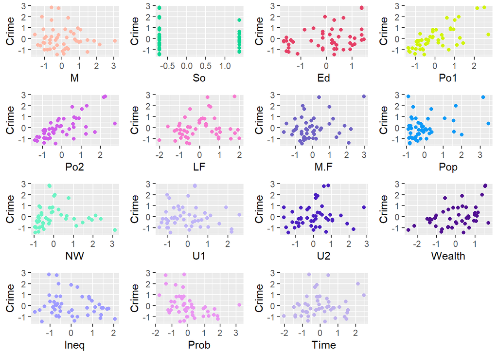

```r
## Function to create scatter plots with new data
scat_plot <- function(i){
  ggplot(data_scaled_t, aes(x = data_scaled_t[,i], y = Crime)) +
    geom_point(weight = 1.5, color = randomColor()) +  xlab(names(data_scaled_t[i]))
}

## Return scatterplots

  do.call(grid.arrange, lapply(1:15, scat_plot))
```

Here, we still see similar correlations, but the data is now centered around (0,0), which allows us to better analyze our information.

Above, we can see that **variable So is a categorical variable.** We will thus remove it from our PCA, as PCA should only be run with numerical variables. I will remove this and rescale the data:

```r
data_scaled <- as.data.frame(scale(crimedata[,-2]))
```

### Principal Component Analysis

Above I explored the visualizations of scaled data to have an understanding of scaling. I will use the **prcomp()** to scale my data in this step. The information from data_scaled will come in use later.

I will also only include the **predictor variables** in the PCA analysis, as the purpose is to reduce the amount and rank only the predictor variables

```r
## first, remove the categorical variable, as it should not be part of
## any PCA
pca_crime <- prcomp(crimedata[, c(1, 3:15)], center = TRUE, scale = TRUE)
summary(pca_crime)
```

```
## Importance of components:
##                           PC1    PC2    PC3     PC4     PC5     PC6     PC7
## Standard deviation     2.3262 1.6513 1.4158 1.03670 0.96745 0.74049 0.56415
## Proportion of Variance 0.3865 0.1948 0.1432 0.07677 0.06685 0.03917 0.02273
## Cumulative Proportion  0.3865 0.5813 0.7244 0.80121 0.86806 0.90723 0.92996
##                            PC8    PC9    PC10    PC11    PC12    PC13    PC14
## Standard deviation     0.54675 0.4475 0.42747 0.35945 0.31852 0.25159 0.06802
## Proportion of Variance 0.02135 0.0143 0.01305 0.00923 0.00725 0.00452 0.00033
## Cumulative Proportion  0.95132 0.9656 0.97867 0.98790 0.99515 0.99967 1.00000
```

Next, I will plot a few of the PC’s of our transformed data to get an idea of what has happened here.

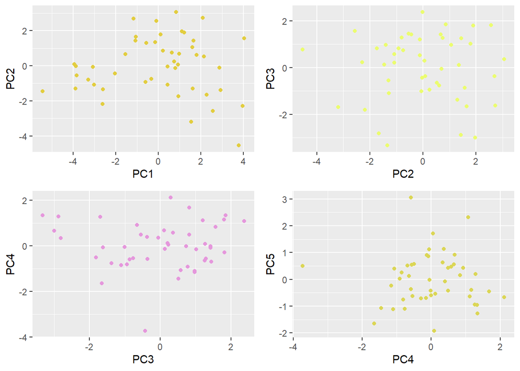

```r
PC1.2 <- ggplot(as.data.frame(pca_crime$x), aes(x = PC1, y = PC2)) + geom_point(weight = 1.5, color = randomColor())
PC2.3 <- ggplot(as.data.frame(pca_crime$x), aes(x = PC2, y = PC3)) + geom_point(weight = 1.5, color = randomColor())
PC3.4 <- ggplot(as.data.frame(pca_crime$x), aes(x = PC3, y = PC4)) + geom_point(weight = 1.5, color = randomColor())
PC4.5 <- ggplot(as.data.frame(pca_crime$x), aes(x = PC4, y = PC5)) + geom_point(weight = 1.5, color = randomColor())
grid.arrange(PC1.2, PC2.3, PC3.4, PC4.5)
```

These graphs show us that the Data has been transformed to run **parallel to the x-axis**, and they are each linear combinations of the different predictor variables.

Now, let’s look at the correlation between all our predictor variables. If we are correct, our correlations should be very close to 0.

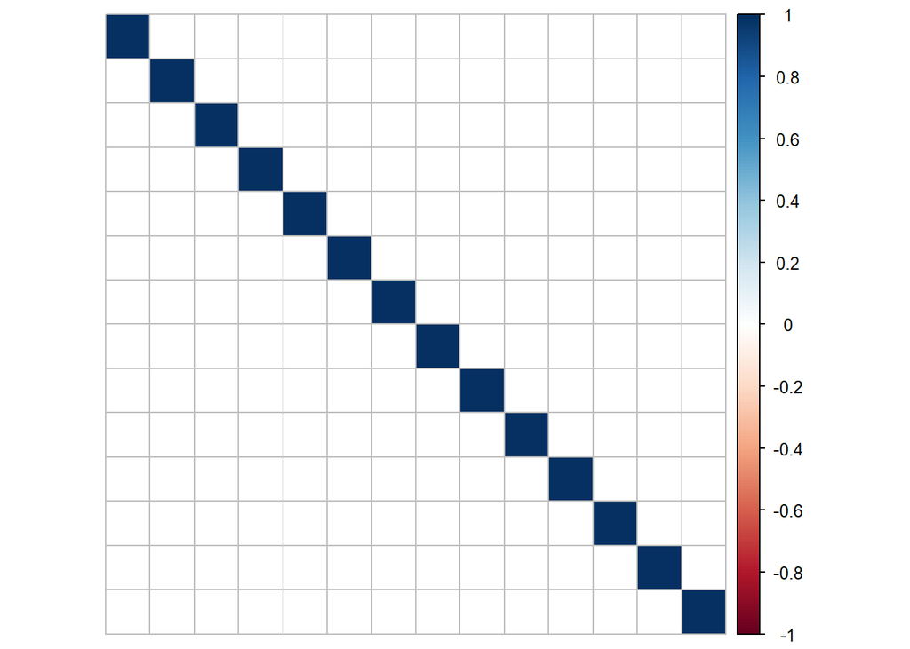

```r
res2 <- cor(pca_crime$x, method="pearson")
corrplot::corrplot(res2, method= "square", order = "AOE", tl.pos = 'n')
```

We next rotate our data based on the rotation values we extracted from our prcomp() model.

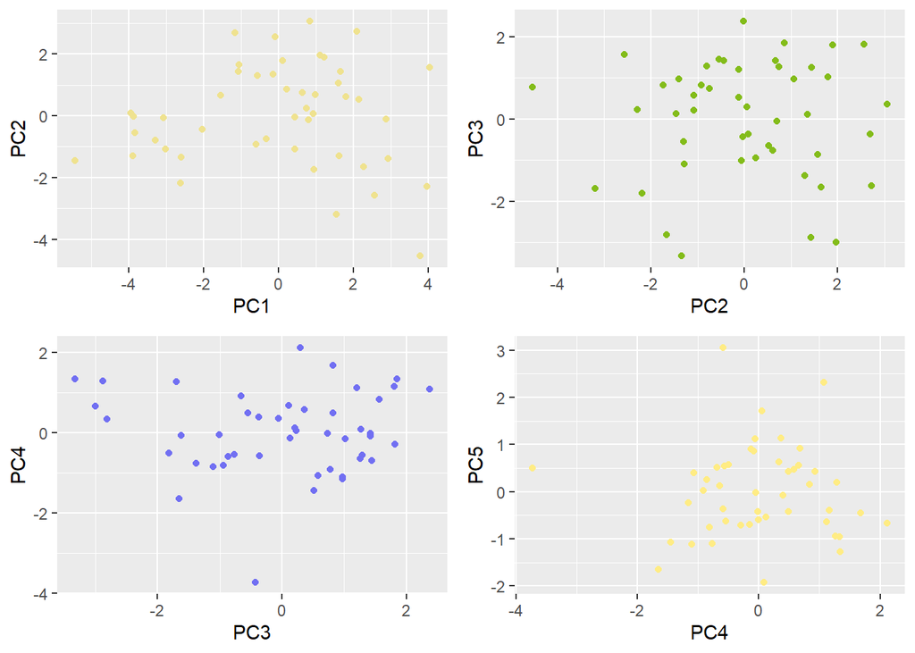

```r
pca_rotated <- as.data.frame(as.matrix(data_scaled[,1:14]) %*% pca_crime$rotation)

PC1.2r <- ggplot(as.data.frame(pca_crime$x), aes(x = PC1, y = PC2)) + geom_point(weight = 1.5, color = randomColor())
PC2.3r <- ggplot(as.data.frame(pca_crime$x), aes(x = PC2, y = PC3)) + geom_point(weight = 1.5, color = randomColor())
PC3.4r <- ggplot(as.data.frame(pca_crime$x), aes(x = PC3, y = PC4)) + geom_point(weight = 1.5, color = randomColor())
PC4.5r <- ggplot(as.data.frame(pca_crime$x), aes(x = PC4, y = PC5)) + geom_point(weight = 1.5, color = randomColor())
grid.arrange(PC1.2r, PC2.3r, PC3.4r, PC4.5r)
```

#### Rotation Matrix

The point of the doing the PCA analysis is to transform our Data. We do this by using the rotation matrix, when is a **matrix of eigenvectors**. We will return to this after we look at the variance and choose the number of principal components

```r
head(pca_crime$rotation)
```

```
##            PC1         PC2         PC3         PC4         PC5          PC6
## M   -0.3207405  0.03436724  0.17404850  0.07531957 0.368062853  0.486976483
## Ed   0.3489898  0.25771322  0.06223132 -0.01364826 0.002566594 -0.009783795
## Po1  0.3475962 -0.22611505  0.04819053 -0.26191345 0.316249218  0.118978277
## Po2  0.3500423 -0.21952098  0.05046073 -0.28698790 0.290831634  0.142732848
## LF   0.1664134  0.33980026  0.26774220  0.26711542 0.328575837 -0.513765721
## M.F  0.1067716  0.41701612 -0.20898396  0.18561154 0.529056112  0.069976867
##             PC7         PC8         PC9        PC10        PC11        PC12
## M    0.06387772 -0.49988379 -0.03422173 -0.44460815  0.16770155 -0.04653385
## Ed  -0.22316660 -0.33791526 -0.45394884  0.32919913  0.52684794  0.21152121
## Po1  0.08788910  0.13925463  0.12681721  0.03646189  0.17139978 -0.30246481
## Po2  0.10713669  0.13104119  0.04438905  0.05399470  0.14082156 -0.26187420
## LF  -0.24086685  0.18167875 -0.07515786 -0.42990348  0.01117046 -0.23707627
## M.F  0.14794900 -0.05048448  0.39933152  0.32736850 -0.21231622  0.25688092
##             PC13         PC14
## M   -0.065026249 -0.005731457
## Ed   0.078293375  0.027517785
## Po1 -0.029925859  0.690414134
## Po2 -0.005549076 -0.719333976
## LF  -0.056099145 -0.030360641
## M.F  0.222518491 -0.010975900
```

#### Choosing the Number of Principal Components

```r
summary(pca_crime)
```

```
## Importance of components:
##                           PC1    PC2    PC3     PC4     PC5     PC6     PC7
## Standard deviation     2.3262 1.6513 1.4158 1.03670 0.96745 0.74049 0.56415
## Proportion of Variance 0.3865 0.1948 0.1432 0.07677 0.06685 0.03917 0.02273
## Cumulative Proportion  0.3865 0.5813 0.7244 0.80121 0.86806 0.90723 0.92996
##                            PC8    PC9    PC10    PC11    PC12    PC13    PC14
## Standard deviation     0.54675 0.4475 0.42747 0.35945 0.31852 0.25159 0.06802
## Proportion of Variance 0.02135 0.0143 0.01305 0.00923 0.00725 0.00452 0.00033
## Cumulative Proportion  0.95132 0.9656 0.97867 0.98790 0.99515 0.99967 1.00000
```

In the above summary, we can see the row **“proportion of variance,**” which shows what **percent of variance has been explained for each number of principal components**.

The below plot looks at what percent variance has been explained for each number of principal components cumulatively.

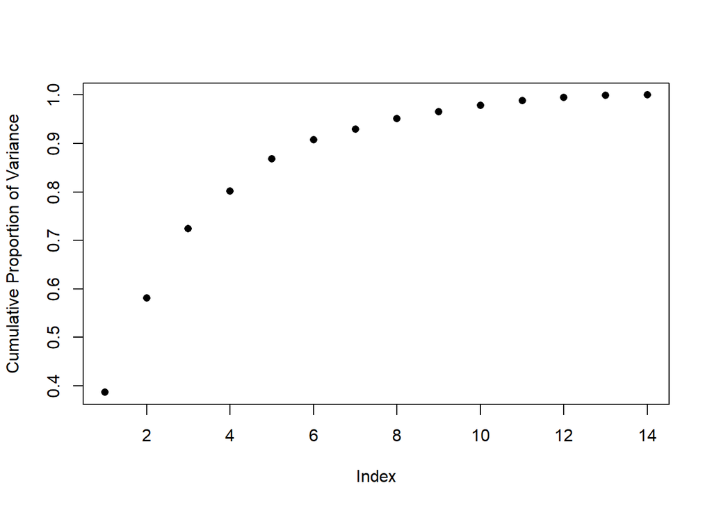

```r
## chart showing the cumalitive proprition of variance
## with each added PC
plot(summary(pca_crime)$importance[3,], ylab = "Cumulative Proportion of Variance", pch = 16)
```

The above is similar to the **screeplot**, which helps us decide how many PC’s we should use to transform our data.

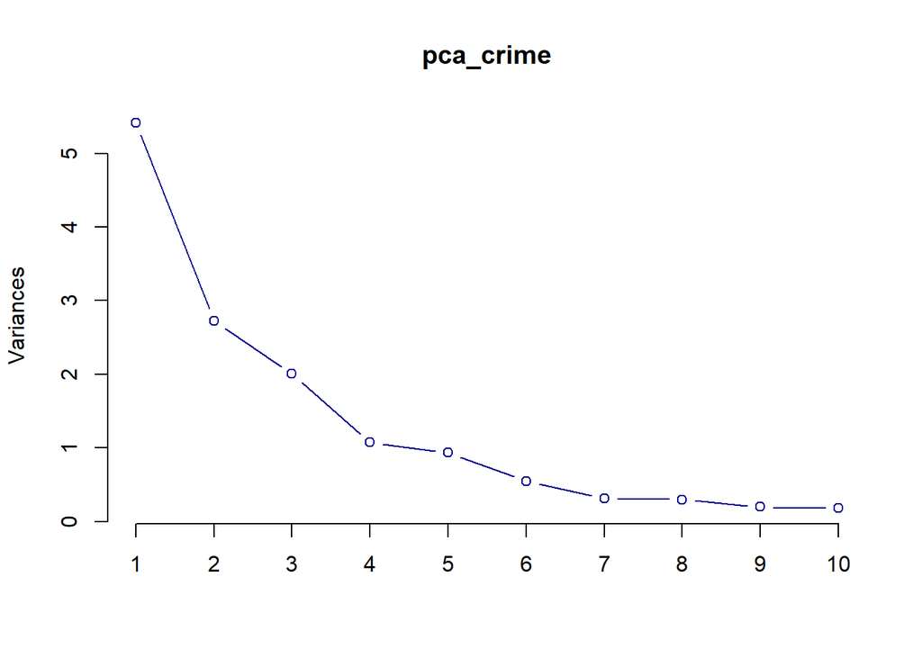

```r
screeplot(pca_crime, type = "line", col = "darkblue")
```

Using both the screeplot and proportion of variance, **I chose to work with 6 Principal Components**. **After 6, the usefulness of each principal component does not seem significant**.

### Linear Regression

I now begin to build the **linear model.** From above, I have chosen to work with **6 principal components.** I then build a new data frame with these principal components and the response variable, crime.

```r
## Extract 6 principle components
pc_crime <- pca_crime$x[,1:6]

## build new data frame
pc_crime_c <- cbind(pc_crime, Crime = crimedata[,16])

##create linear model
pc_lm <- lm(Crime~., data = as.data.frame(pc_crime_c))
summary(pc_lm)
```

```
##
## Call:
## lm(formula = Crime ~ ., data = as.data.frame(pc_crime_c))
##
## Residuals:
##     Min      1Q  Median      3Q     Max
## -399.15 -166.78   15.28  150.91  452.53
##
## Coefficients:
##             Estimate Std. Error t value Pr(>|t|)
## (Intercept)  905.085     36.058  25.101  < 2e-16 ***
## PC1           76.750     15.668   4.898 1.64e-05 ***
## PC2          -57.648     22.072  -2.612   0.0126 *
## PC3           24.313     25.744   0.944   0.3506
## PC4           -3.786     35.157  -0.108   0.9148
## PC5          235.831     37.674   6.260 2.04e-07 ***
## PC6           64.174     49.221   1.304   0.1998
## ---
## Signif. codes:  0 '***' 0.001 '**' 0.01 '*' 0.05 '.' 0.1 ' ' 1
##
## Residual standard error: 247.2 on 40 degrees of freedom
## Multiple R-squared:  0.6448, Adjusted R-squared:  0.5915
## F-statistic:  12.1 on 6 and 40 DF,  p-value: 1.036e-07
```

### Transforming the Data

The next step is to get our **“alphas”** that are in terms of the original scaled variables. To do this, we do some matrix multiplication. First, I create a data matrix with just the coefficients for my own ease of use. I create a separate frame for the **intercept, beta_0**. Then, using our **rotation matrix from earlier (pca_crime$rotation), we multiple this through our beta coefficients form our linear model**. With our coefficients, we have to be aware not to include the intercept, but we DO have to transform it separately.

```r
## Create a data frame with the coefficients
## the first is for intercept, the second is for all other coefficients
beta_0 <- pc_lm$coefficients[1]
betas <- pc_lm$coefficients[-1]

## compute alphas by applying the transformation left to right

alphas <- pca_crime$rotation[,1:6] %*% betas
alphas
```

```
##              [,1]
## M       95.400235
## Ed      13.470475
## Po1    124.092698
## Po2    119.580606
## LF      43.199820
## M.F    107.629381
## Pop     28.786137
## NW     103.806024
## U1       2.756535
## U2      29.061629
## Wealth  38.505494
## Ineq     8.489242
## Prob   -43.150501
## Time    35.340376
```

Now we have our alpha values, but we cannot yet use them because they are scaled.

```r
## unscaled interept
uns_beta0 <- beta_0 - sum(alphas * sapply(crimedata[,c(1, 3:15)],mean)/sapply(crimedata[,c(1, 3:15)],sd))

## unscaled alphas, making sure to take into account exclusion of So
unscaled_alphas <- alphas / sapply(crimedata[,c(1, 3:15)],sd)
```

### Prediction

This table of **alpha values is the coefficients we will apply to our test poin**t. We do this through matrix multiplication. Value So will be removed from the test point, as it was removed for being a categorical variable. Because So is 0 in the test point, removing it from the set will not make a difference.

```r
## read in test point
test_point <- data.frame(M = 14.0, Ed = 10.0, Po1 = 12.0, Po2 = 15.5, LF = 0.640, M.F = 94.0, Pop = 150, NW = 1.1, U1 = 0.120, U2 = 3.6, Wealth = 3200, Ineq = 20.1, Prob = 0.04, Time = 39.0)

## our prediction is the matrix multiplaction of alphas and test points
## plus the intercept
prediction <- (as.matrix(test_point) %*% as.matrix(unscaled_alphas)) + uns_beta0

prediction
```

```
##          [,1]
## [1,] 1302.405
```

**Our prediction is 1302.405**

### Conclusion

1. This linear regression model after isolating the 6 **Principal Components** with the highest variance predicts a crime rate of approximately *1302.405.* This prediction seems to be in line with other data points that contain similar predictors.
2. The categorical variable **So** was excluded before computing the **PCA** and was never reintroduced. It wouldn’t have made a difference since its value is 0 in the new observation.
3. Here’s a description of the approach I presented last week in getting to *Prediction = 957.369.*
   > - I created three linear models to test the crime data, one with all of the data, one with a lower amount of data, and one with the response variable transformed by the natural log. I then looked at the $R^2$ values and the p-values. A higher $R^2$ and lower p-value indicates better goodness of fit for our model.
   > - I chose to disregard the first model with all variables because there was collinearity among two sets of predictor variables. While it had the highest $R^2$, I did not trust it.